# regression

```r
cor(Auto[,1:8])
```

```
##                 mpg cylinders displacement horsepower weight acceleration
## mpg           1.000    -0.778       -0.805     -0.778 -0.832        0.423
## cylinders    -0.778     1.000        0.951      0.843  0.898       -0.505
## displacement -0.805     0.951        1.000      0.897  0.933       -0.544
## horsepower   -0.778     0.843        0.897      1.000  0.865       -0.689
## weight       -0.832     0.898        0.933      0.865  1.000       -0.417
## acceleration  0.423    -0.505       -0.544     -0.689 -0.417        1.000
## year          0.581    -0.346       -0.370     -0.416 -0.309        0.290
## origin        0.565    -0.569       -0.615     -0.455 -0.585        0.213
##                year origin
## mpg           0.581  0.565
## cylinders    -0.346 -0.569
## displacement -0.370 -0.615
## horsepower   -0.416 -0.455
## weight       -0.309 -0.585
## acceleration  0.290  0.213
## year          1.000  0.182
## origin        0.182  1.000
```

multiple linear regression without name

```r
MLAuto=lm(mpg ~.-name,data = Auto)
summary(MLAuto)
```

```
##
## Call:
## lm(formula = mpg ~ . - name, data = Auto)
##
## Residuals:
##    Min     1Q Median     3Q    Max
## -9.590 -2.157 -0.117  1.869 13.060
##
## Coefficients:
##               Estimate Std. Error t value Pr(>|t|)
## (Intercept)  -1.72e+01   4.64e+00   -3.71  0.00024 ***
## cylinders    -4.93e-01   3.23e-01   -1.53  0.12780
## displacement  1.99e-02   7.51e-03    2.65  0.00844 **
## horsepower   -1.70e-02   1.38e-02   -1.23  0.21963
## weight       -6.47e-03   6.52e-04   -9.93  < 2e-16 ***
## acceleration  8.06e-02   9.88e-02    0.82  0.41548
## year          7.51e-01   5.10e-02   14.73  < 2e-16 ***
## origin        1.43e+00   2.78e-01    5.13  4.7e-07 ***
## ---
## Signif. codes:  0 '***' 0.001 '**' 0.01 '*' 0.05 '.' 0.1 ' ' 1
##
## Residual standard error: 3.33 on 384 degrees of freedom
## Multiple R-squared:  0.821,  Adjusted R-squared:  0.818
## F-statistic:  252 on 7 and 384 DF,  p-value: <2e-16
```

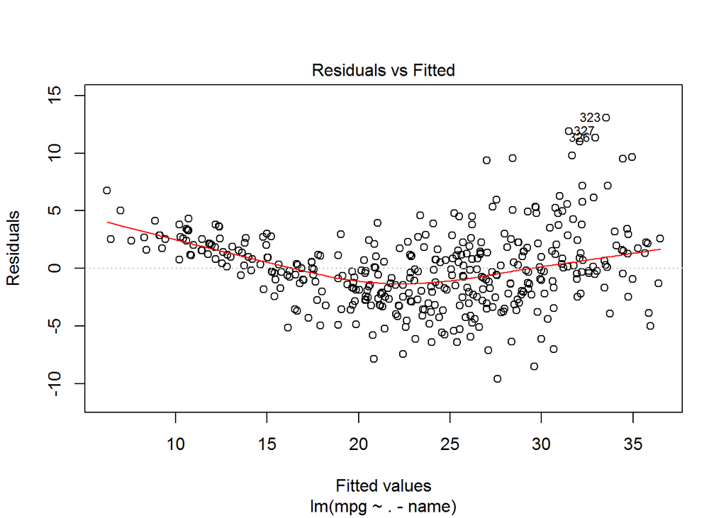

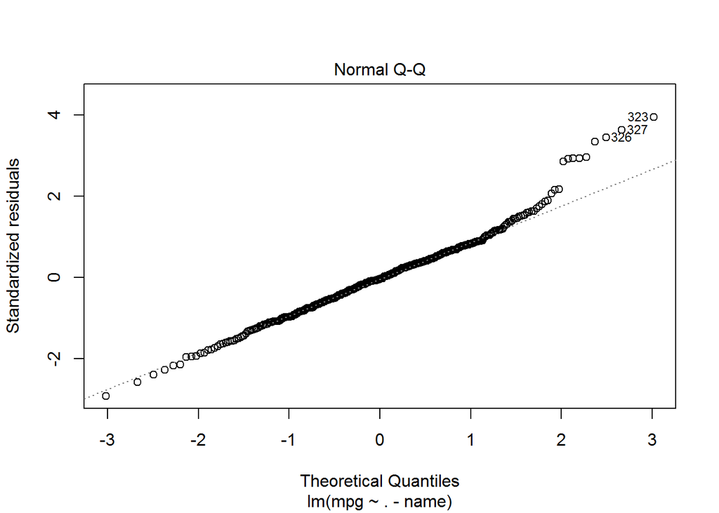

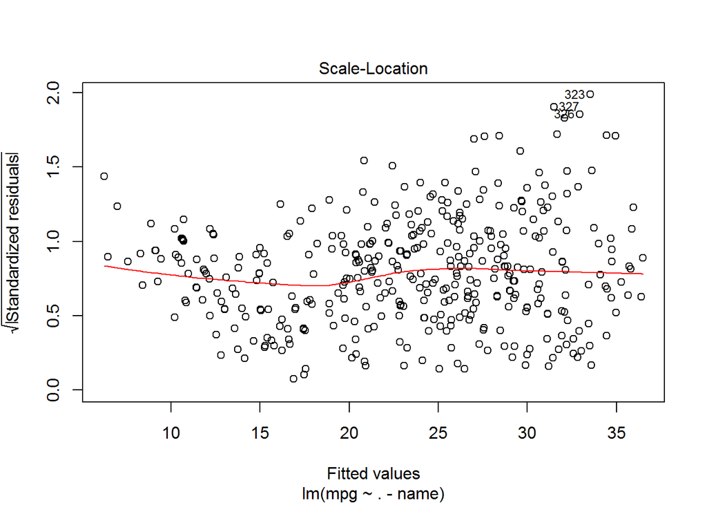

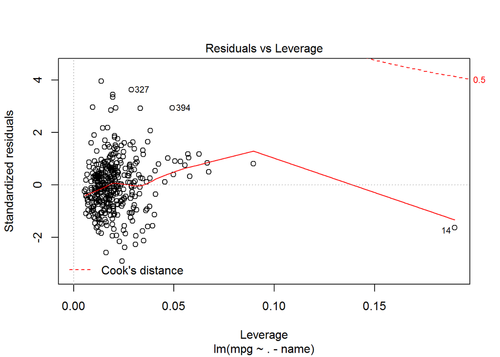

```r
plot(MLAuto)
```

interactions

```r
MLAuto=lm(mpg ~horsepower^2+sqrt(weight)
          +year+origin+
            I(horsepower*weight),data = Auto)
summary(MLAuto)
```

```
##
## Call:
## lm(formula = mpg ~ horsepower^2 + sqrt(weight) + year + origin +
##     I(horsepower * weight), data = Auto)
##
## Residuals:
##    Min     1Q Median     3Q    Max
## -8.882 -1.692 -0.162  1.563 12.194
##
## Coefficients:
##                         Estimate Std. Error t value Pr(>|t|)
## (Intercept)             2.39e+01   4.61e+00    5.18  3.7e-07 ***
## horsepower             -1.63e-01   1.91e-02   -8.52  3.6e-16 ***
## sqrt(weight)           -1.06e+00   6.06e-02  -17.42  < 2e-16 ***
## year                    7.78e-01   4.47e-02   17.39  < 2e-16 ***
## origin                  6.45e-01   2.35e-01    2.75   0.0063 **
## I(horsepower * weight)  3.99e-05   4.40e-06    9.07  < 2e-16 ***
## ---
## Signif. codes:  0 '***' 0.001 '**' 0.01 '*' 0.05 '.' 0.1 ' ' 1
##
## Residual standard error: 2.93 on 386 degrees of freedom
## Multiple R-squared:  0.861,  Adjusted R-squared:  0.859
## F-statistic:  477 on 5 and 386 DF,  p-value: <2e-16
```

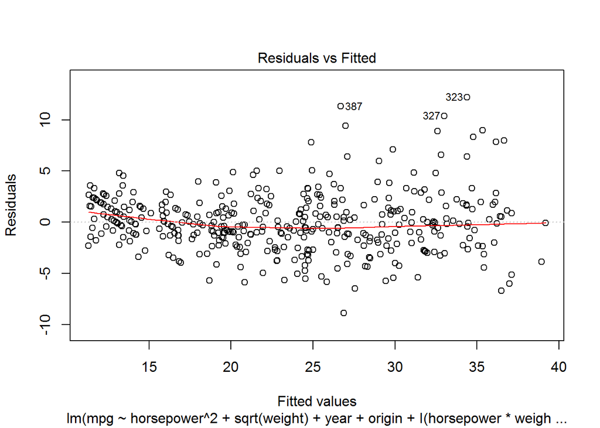

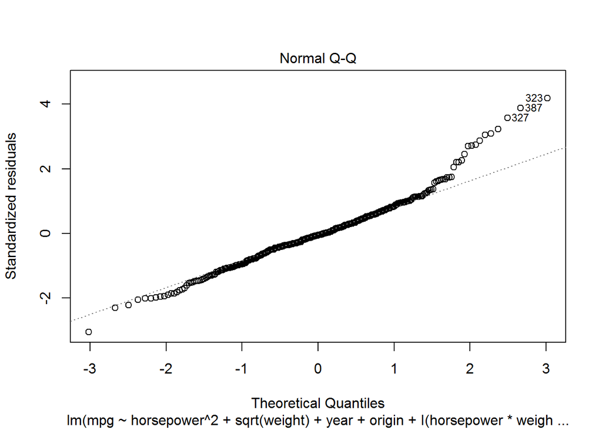

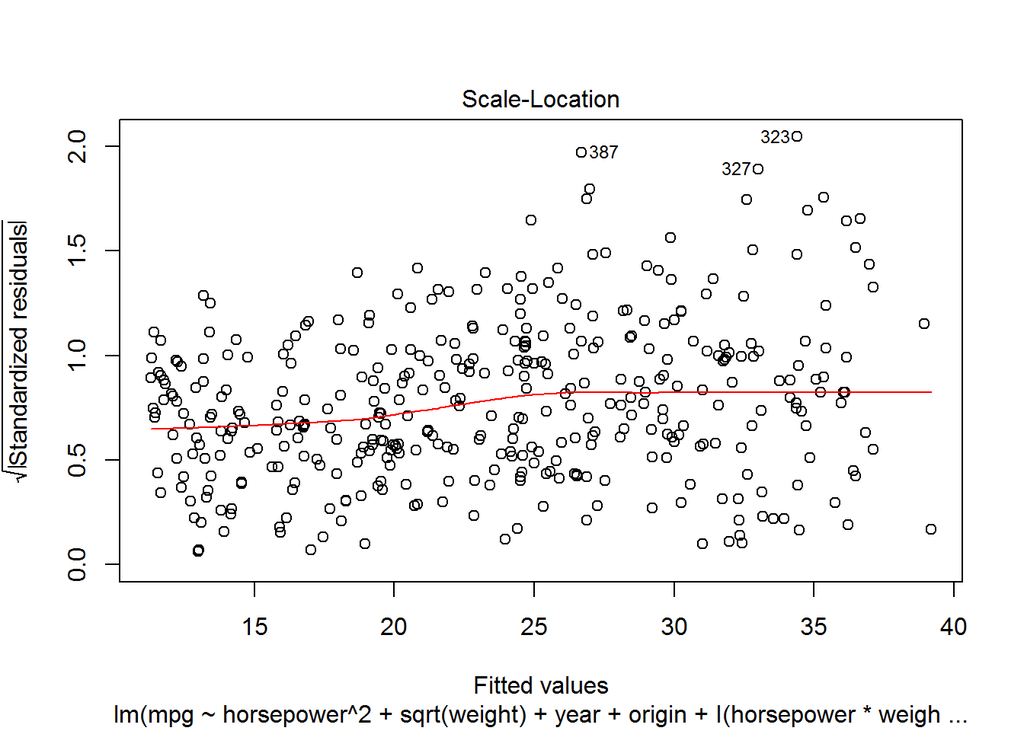

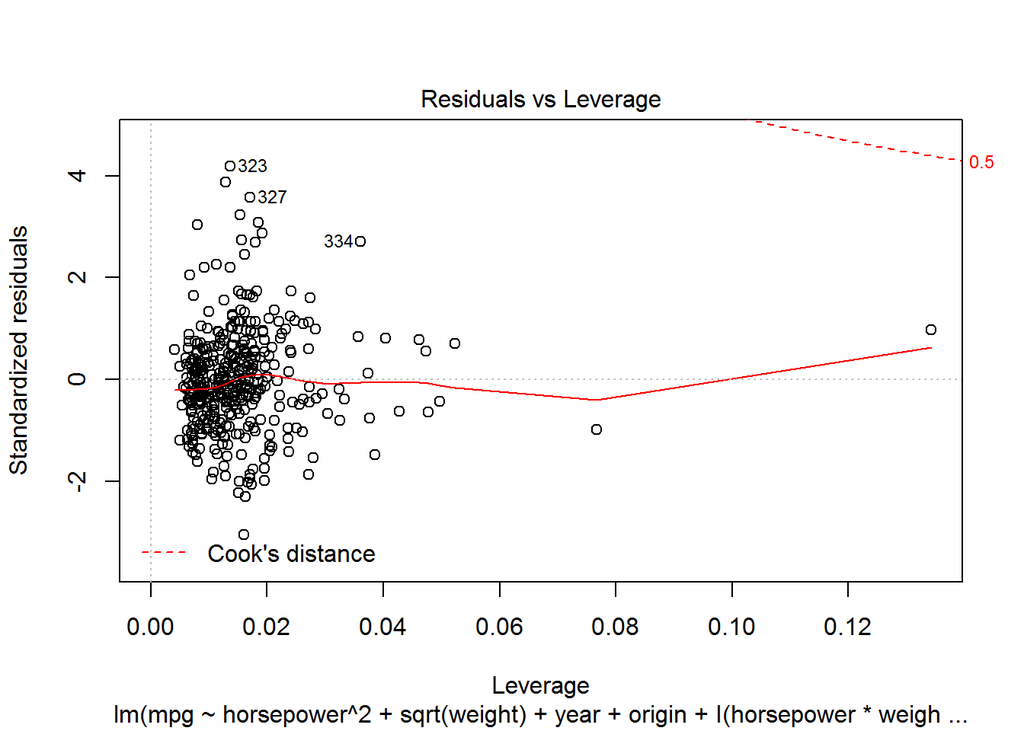

```r
plot(MLAuto)
```

Question 10

```r
attach(Carseats)
Q10=lm(Sales~Price+Urban+US)
summary(Q10)
```

```
##
## Call:
## lm(formula = Sales ~ Price + Urban + US)
##
## Residuals:
##    Min     1Q Median     3Q    Max
## -6.921 -1.622 -0.056  1.579  7.058
##
## Coefficients:
##             Estimate Std. Error t value Pr(>|t|)
## (Intercept) 13.04347    0.65101   20.04  < 2e-16 ***
## Price       -0.05446    0.00524  -10.39  < 2e-16 ***
## UrbanYes    -0.02192    0.27165   -0.08     0.94
## USYes        1.20057    0.25904    4.63  4.9e-06 ***
## ---
## Signif. codes:  0 '***' 0.001 '**' 0.01 '*' 0.05 '.' 0.1 ' ' 1
##
## Residual standard error: 2.47 on 396 degrees of freedom
## Multiple R-squared:  0.239,  Adjusted R-squared:  0.234
## F-statistic: 41.5 on 3 and 396 DF,  p-value: <2e-16
```

```r
coef(Q10)
```

```
## (Intercept)       Price    UrbanYes       USYes
##     13.0435     -0.0545     -0.0219      1.2006
```

remooving urban, as it is insignificant

```r
attach(Carseats)
Q10.2=lm(Sales~Price+US)
summary(Q10.2)
```

```
##
## Call:
## lm(formula = Sales ~ Price + US)
##
## Residuals:
##    Min     1Q Median     3Q    Max
## -6.927 -1.629 -0.057  1.577  7.052
##
## Coefficients:
##             Estimate Std. Error t value Pr(>|t|)
## (Intercept) 13.03079    0.63098   20.65  < 2e-16 ***
## Price       -0.05448    0.00523  -10.42  < 2e-16 ***
## USYes        1.19964    0.25846    4.64  4.7e-06 ***
## ---
## Signif. codes:  0 '***' 0.001 '**' 0.01 '*' 0.05 '.' 0.1 ' ' 1
##
## Residual standard error: 2.47 on 397 degrees of freedom
## Multiple R-squared:  0.239,  Adjusted R-squared:  0.235
## F-statistic: 62.4 on 2 and 397 DF,  p-value: <2e-16
```

```r
coef(Q10.2)
```

```
## (Intercept)       Price       USYes
##     13.0308     -0.0545      1.1996
```

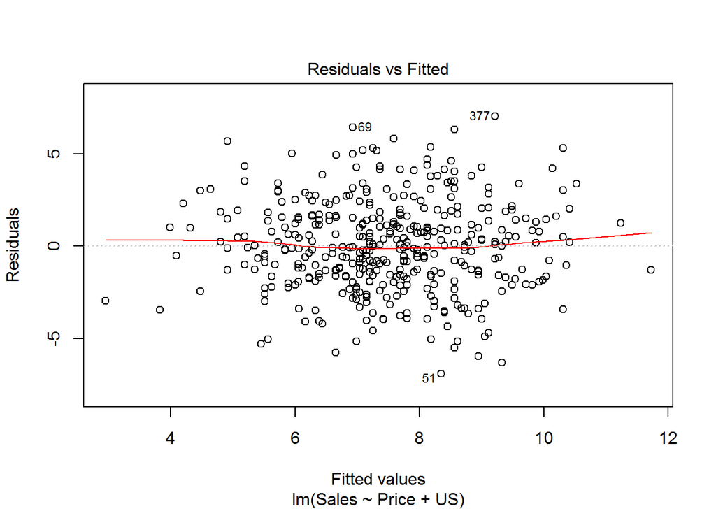

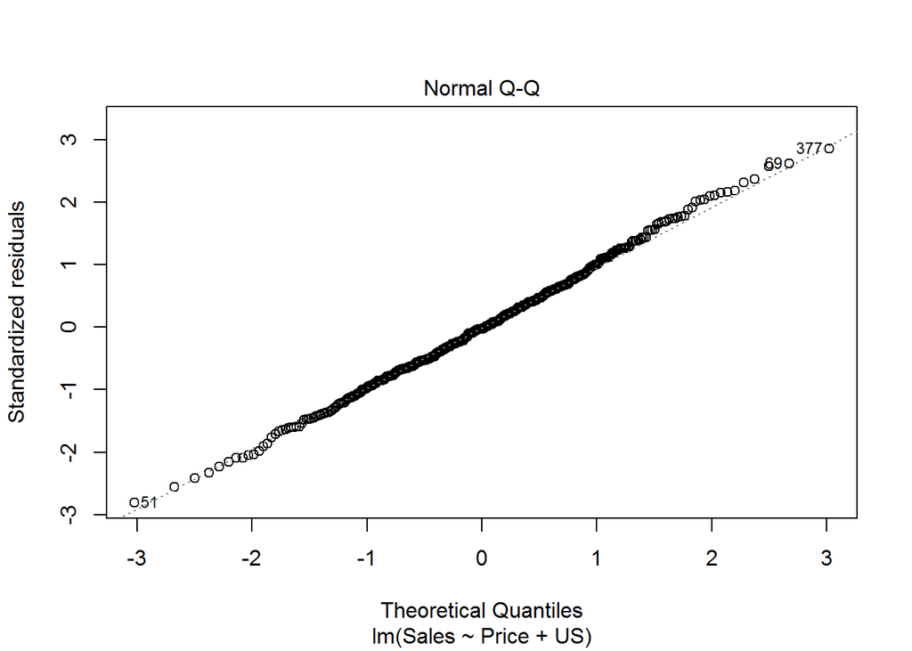

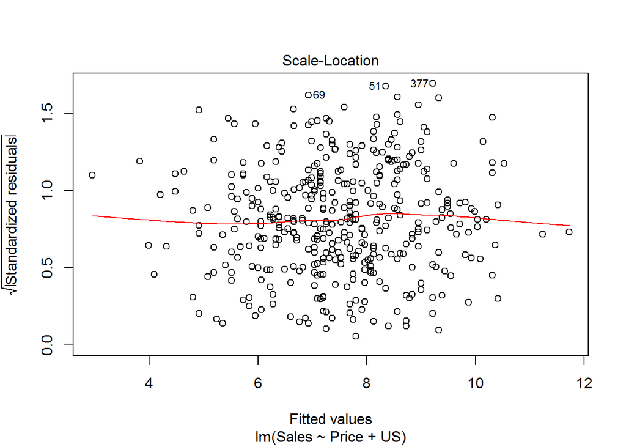

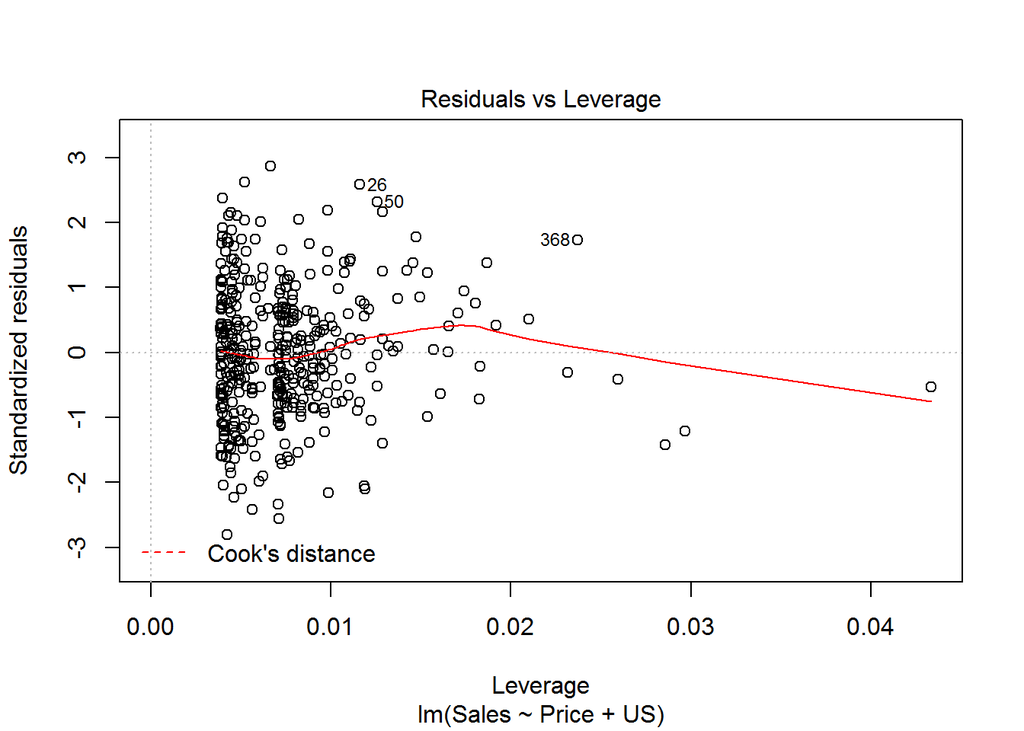

```r
plot(Q10.2)
```

confidence intervals

```r
confint(Q10.2)
```

```
##               2.5 %  97.5 %
## (Intercept) 11.7903 14.2713
## Price       -0.0648 -0.0442
## USYes        0.6915  1.7078
```

t-statistic investigation

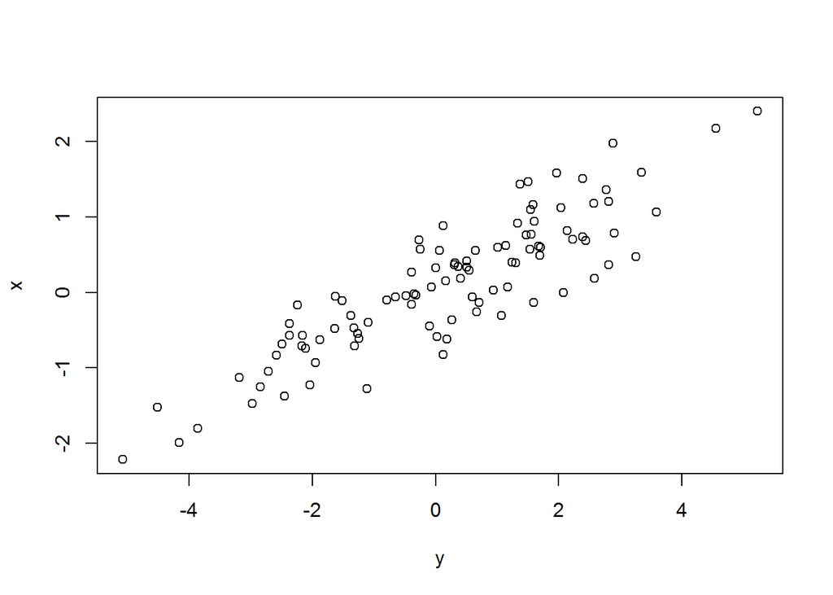

```r
set.seed(1)
x=rnorm(100)
y=2*x+rnorm(100)
plot(y,x)
```

simple linear regression on above generated data

```r
Q11=lm(y~x)
summary(Q11)
```

```
##
## Call:
## lm(formula = y ~ x)
##
## Residuals:
##    Min     1Q Median     3Q    Max
## -1.877 -0.614 -0.140  0.539  2.346
##
## Coefficients:
##             Estimate Std. Error t value Pr(>|t|)
## (Intercept)  -0.0377     0.0970   -0.39      0.7
## x             1.9989     0.1077   18.56   <2e-16 ***
## ---
## Signif. codes:  0 '***' 0.001 '**' 0.01 '*' 0.05 '.' 0.1 ' ' 1
##
## Residual standard error: 0.963 on 98 degrees of freedom
## Multiple R-squared:  0.778,  Adjusted R-squared:  0.776
## F-statistic:  344 on 1 and 98 DF,  p-value: <2e-16
```

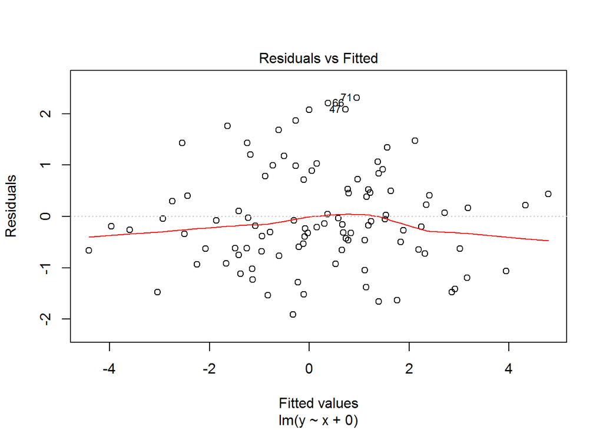

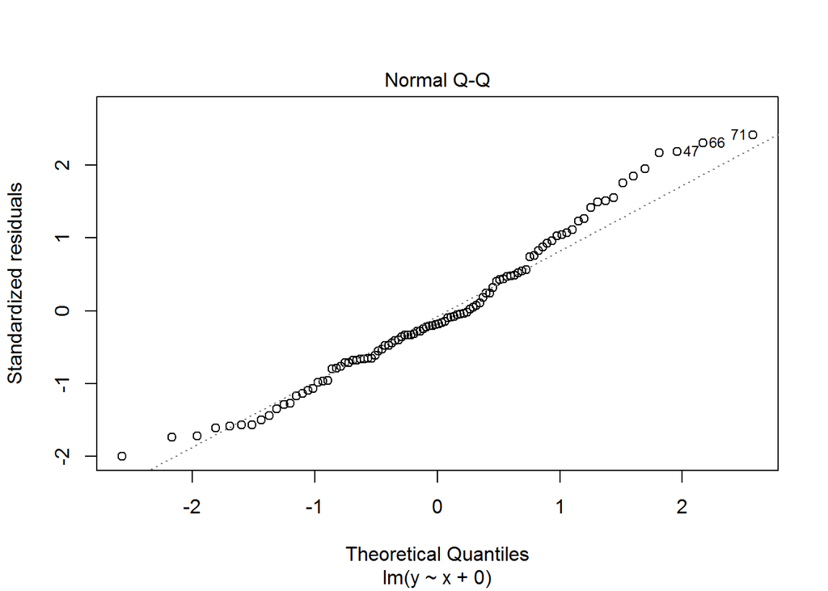

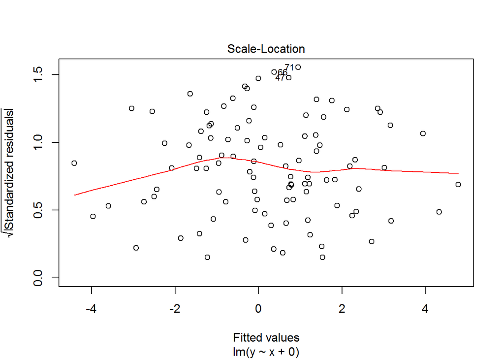

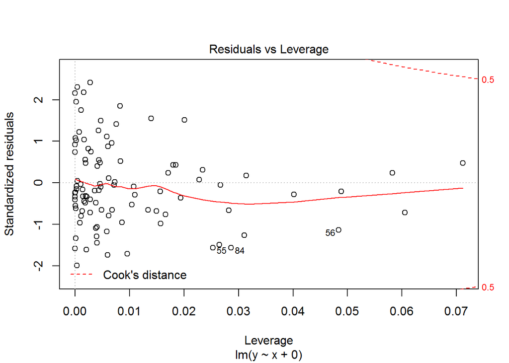

```r
Q11.2=lm(y~x+0)
plot(Q11.2)
```

```r
summary(Q11.2)
```

```
##
## Call:
## lm(formula = y ~ x + 0)
##
## Residuals:
##    Min     1Q Median     3Q    Max
## -1.915 -0.647 -0.177  0.506  2.311
##
## Coefficients:
##   Estimate Std. Error t value Pr(>|t|)
## x    1.994      0.106    18.7   <2e-16 ***
## ---
## Signif. codes:  0 '***' 0.001 '**' 0.01 '*' 0.05 '.' 0.1 ' ' 1
##
## Residual standard error: 0.959 on 99 degrees of freedom
## Multiple R-squared:  0.78,   Adjusted R-squared:  0.778
## F-statistic:  351 on 1 and 99 DF,  p-value: <2e-16
```

checking for x onto y and y onto x go trough it, u will find it interesting

```r
set.seed(12)
x=rnorm(100)
set.seed(12)
y=rnorm(100)
Q12=lm(x~y+0)
Q12.2=lm(y~x+0)
summary(Q12)
```

```
##
## Call:
## lm(formula = x ~ y + 0)
##
## Residuals:
##       Min        1Q    Median        3Q       Max
## -3.47e-16 -4.00e-17 -3.00e-18  3.50e-17  4.98e-15
##
## Coefficients:
##   Estimate Std. Error  t value Pr(>|t|)
## y 1.00e+00   5.93e-17 1.69e+16   <2e-16 ***
## ---
## Signif. codes:  0 '***' 0.001 '**' 0.01 '*' 0.05 '.' 0.1 ' ' 1
##
## Residual standard error: 5.11e-16 on 99 degrees of freedom
## Multiple R-squared:     1,   Adjusted R-squared:     1
## F-statistic: 2.85e+32 on 1 and 99 DF,  p-value: <2e-16
```

```r
summary(Q12.2)
```

```
##
## Call:
## lm(formula = y ~ x + 0)
##
## Residuals:
##       Min        1Q    Median        3Q       Max
## -3.47e-16 -4.00e-17 -3.00e-18  3.50e-17  4.98e-15
##
## Coefficients:
##   Estimate Std. Error  t value Pr(>|t|)
## x 1.00e+00   5.93e-17 1.69e+16   <2e-16 ***
## ---
## Signif. codes:  0 '***' 0.001 '**' 0.01 '*' 0.05 '.' 0.1 ' ' 1
##
## Residual standard error: 5.11e-16 on 99 degrees of freedom
## Multiple R-squared:     1,   Adjusted R-squared:     1
## F-statistic: 2.85e+32 on 1 and 99 DF,  p-value: <2e-16
```

question 13

```r
set.seed(1)
x=rnorm(100,mean = 0,sd = 1)
eps=rnorm(100,mean=0,sd=0.25)
y=-1+.5*x+eps
length(y)
```

```
## [1] 100
```

```r
Q13=lm(y~x)
coef(Q13)
```

```
## (Intercept)           x
##       -1.01        0.50
```

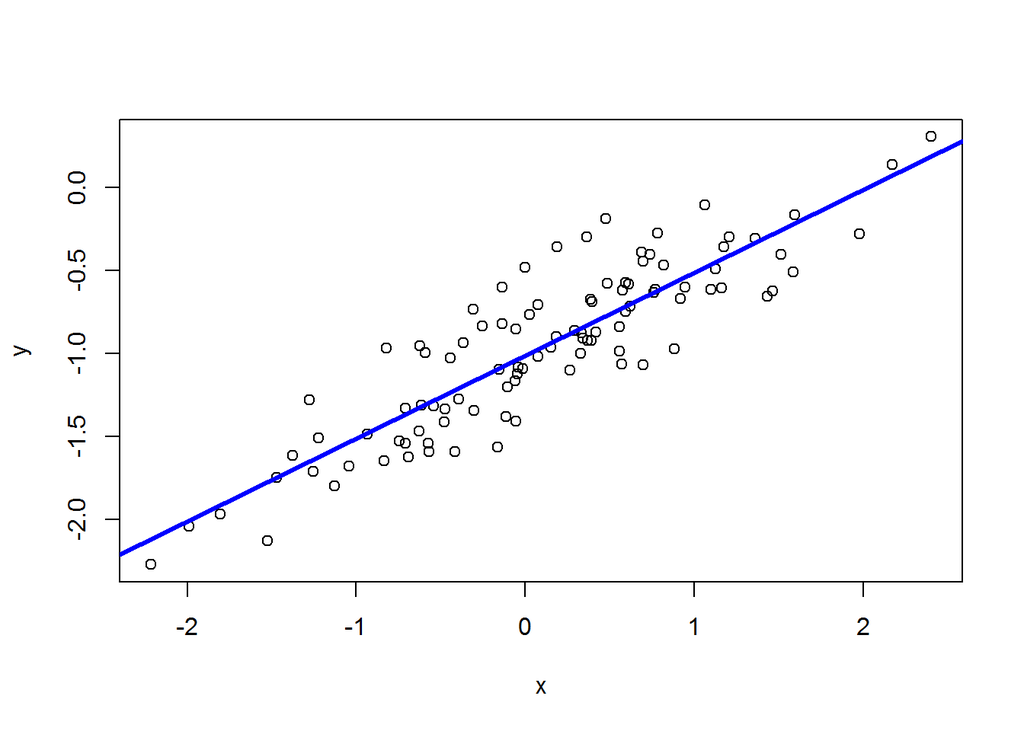

```r
plot(x,y)
abline(Q13,lwd=3,col="blue")
```

polynomial regression

```r
Q13.2=lm(y~poly(x,2))
coef(Q13.2)
```

```
## (Intercept) poly(x, 2)1 poly(x, 2)2
##      -0.955       4.466      -0.336
```

```r
summary(Q13)
```

```
##
## Call:
## lm(formula = y ~ x)
##
## Residuals:
##     Min      1Q  Median      3Q     Max
## -0.4692 -0.1534 -0.0349  0.1349  0.5865
##
## Coefficients:
##             Estimate Std. Error t value Pr(>|t|)
## (Intercept)  -1.0094     0.0242   -41.6   <2e-16 ***
## x             0.4997     0.0269    18.6   <2e-16 ***
## ---
## Signif. codes:  0 '***' 0.001 '**' 0.01 '*' 0.05 '.' 0.1 ' ' 1
##
## Residual standard error: 0.241 on 98 degrees of freedom
## Multiple R-squared:  0.778,  Adjusted R-squared:  0.776
## F-statistic:  344 on 1 and 98 DF,  p-value: <2e-16
```

```r
summary(Q13.2)
```

```
##
## Call:
## lm(formula = y ~ poly(x, 2))
##
## Residuals:
##     Min      1Q  Median      3Q     Max
## -0.4913 -0.1563 -0.0322  0.1451  0.5675
##
## Coefficients:
##             Estimate Std. Error t value Pr(>|t|)
## (Intercept)   -0.955      0.024   -39.9   <2e-16 ***
## poly(x, 2)1    4.466      0.239    18.6   <2e-16 ***
## poly(x, 2)2   -0.336      0.239    -1.4     0.16
## ---
## Signif. codes:  0 '***' 0.001 '**' 0.01 '*' 0.05 '.' 0.1 ' ' 1
##
## Residual standard error: 0.24 on 97 degrees of freedom
## Multiple R-squared:  0.783,  Adjusted R-squared:  0.778
## F-statistic:  175 on 2 and 97 DF,  p-value: <2e-16
```

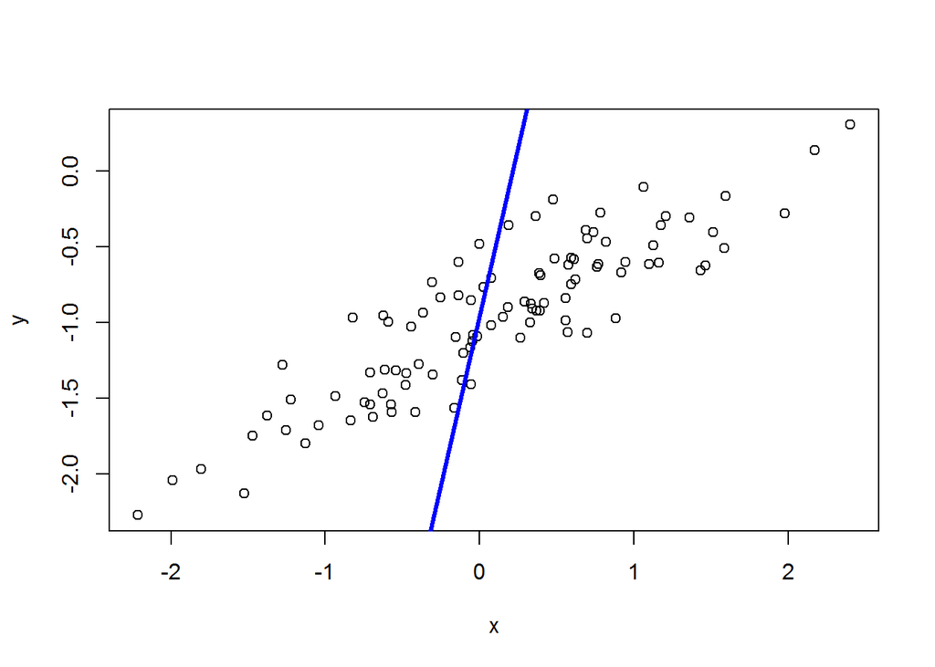

```r
plot(x,y)
abline(Q13.2,lwd=3,col="blue")
```

less variance in error

```r
set.seed(1)
x=rnorm(100,mean = 0,sd = 1)
eps=rnorm(100,mean=0,sd=0.1)
y=-1+.5*x+eps
length(y)
```

```
## [1] 100
```

```r
Q13.3=lm(y~x)
coef(Q13.3)
```

```
## (Intercept)           x
##        -1.0         0.5
```

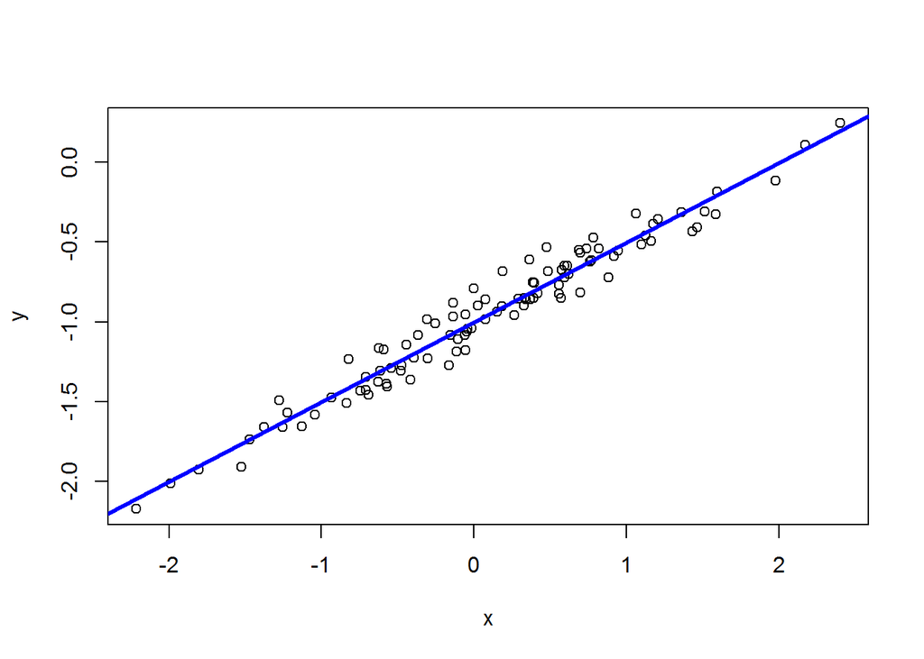

```r
plot(x,y)
abline(Q13.3,lwd=3,col="blue")
```

polynomial regressio

```r
Q13.4=lm(y~poly(x,2))
coef(Q13.2)
```

```
## (Intercept) poly(x, 2)1 poly(x, 2)2
##      -0.955       4.466      -0.336
```

```r
summary(Q13.3)
```

```
##
## Call:
## lm(formula = y ~ x)
##
## Residuals:
##     Min      1Q  Median      3Q     Max
## -0.1877 -0.0614 -0.0140  0.0539  0.2346
##
## Coefficients:
##             Estimate Std. Error t value Pr(>|t|)
## (Intercept)  -1.0038     0.0097  -103.5   <2e-16 ***
## x             0.4999     0.0108    46.4   <2e-16 ***
## ---
## Signif. codes:  0 '***' 0.001 '**' 0.01 '*' 0.05 '.' 0.1 ' ' 1
##
## Residual standard error: 0.0963 on 98 degrees of freedom
## Multiple R-squared:  0.956,  Adjusted R-squared:  0.956
## F-statistic: 2.15e+03 on 1 and 98 DF,  p-value: <2e-16
```

```r
summary(Q13.4)
```

```
##
## Call:
## lm(formula = y ~ poly(x, 2))
##
## Residuals:
##     Min      1Q  Median      3Q     Max
## -0.1965 -0.0625 -0.0129  0.0580  0.2270
##
## Coefficients:
##             Estimate Std. Error t value Pr(>|t|)
## (Intercept) -0.94934    0.00958   -99.1   <2e-16 ***
## poly(x, 2)1  4.46754    0.09580    46.6   <2e-16 ***
## poly(x, 2)2 -0.13441    0.09580    -1.4     0.16
## ---
## Signif. codes:  0 '***' 0.001 '**' 0.01 '*' 0.05 '.' 0.1 ' ' 1
##
## Residual standard error: 0.0958 on 97 degrees of freedom
## Multiple R-squared:  0.957,  Adjusted R-squared:  0.956
## F-statistic: 1.09e+03 on 2 and 97 DF,  p-value: <2e-16
```

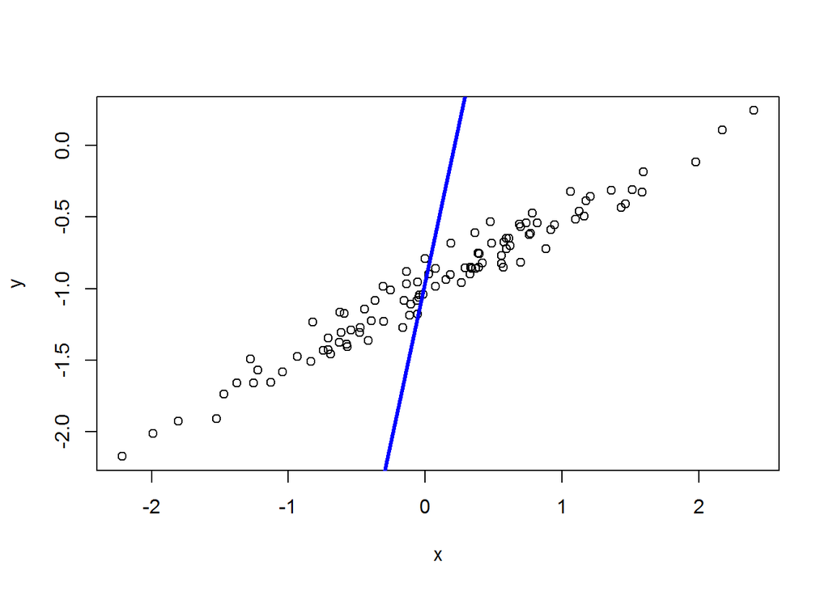

```r
plot(x,y)
abline(Q13.4,lwd=3,col="blue")
```

more variance in errors

```r
set.seed(1)
x=rnorm(100,mean = 0,sd = 1)
eps=rnorm(100,mean=0,sd=0.5)
y=-1+.5*x+eps
length(y)
```

```
## [1] 100
```

```r
Q13.5=lm(y~x)
coef(Q13.5)
```

```
## (Intercept)           x
##      -1.019       0.499
```

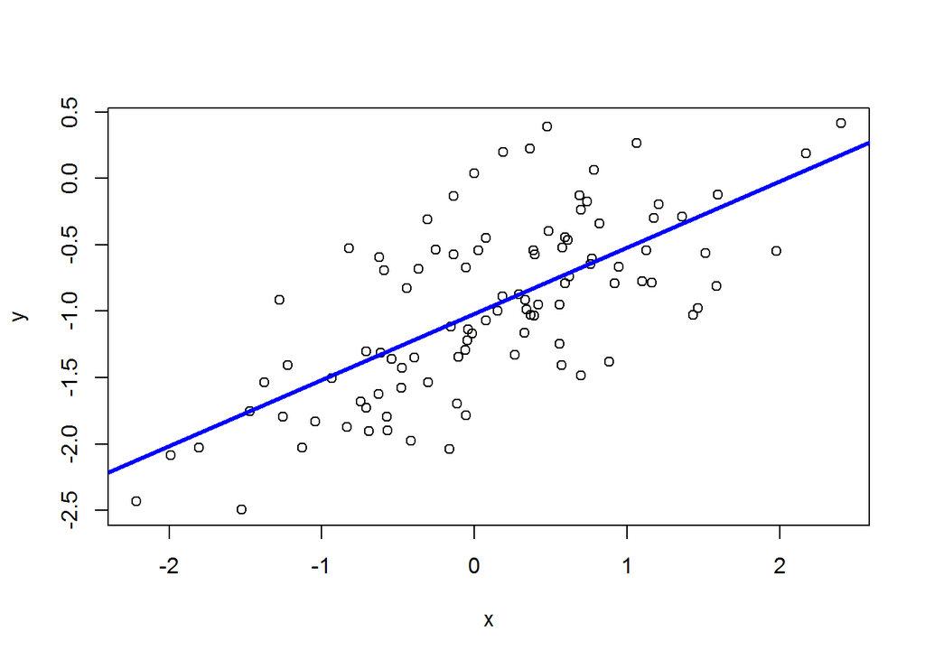

```r
plot(x,y)
abline(Q13.5,lwd=3,col="blue")
```

polynomial regression

```r
Q13.6=lm(y~poly(x,2))
coef(Q13.6)
```

```
## (Intercept) poly(x, 2)1 poly(x, 2)2
##      -0.964       4.464      -0.672
```

```r
summary(Q13.5)
```

```
##
## Call:
## lm(formula = y ~ x)
##
## Residuals:
##     Min      1Q  Median      3Q     Max
## -0.9384 -0.3069 -0.0697  0.2697  1.1731
##
## Coefficients:
##             Estimate Std. Error t value Pr(>|t|)
## (Intercept)  -1.0188     0.0485  -21.01  < 2e-16 ***
## x             0.4995     0.0539    9.27  4.6e-15 ***
## ---
## Signif. codes:  0 '***' 0.001 '**' 0.01 '*' 0.05 '.' 0.1 ' ' 1
##
## Residual standard error: 0.481 on 98 degrees of freedom
## Multiple R-squared:  0.467,  Adjusted R-squared:  0.462
## F-statistic:   86 on 1 and 98 DF,  p-value: 4.58e-15
```

```r
summary(Q13.6)
```

```
##
## Call:
## lm(formula = y ~ poly(x, 2))
##
## Residuals:
##     Min      1Q  Median      3Q     Max
## -0.9825 -0.3127 -0.0644  0.2901  1.1350
##
## Coefficients:
##             Estimate Std. Error t value Pr(>|t|)
## (Intercept)  -0.9645     0.0479  -20.13   <2e-16 ***
## poly(x, 2)1   4.4637     0.4790    9.32    4e-15 ***
## poly(x, 2)2  -0.6720     0.4790   -1.40     0.16
## ---
## Signif. codes:  0 '***' 0.001 '**' 0.01 '*' 0.05 '.' 0.1 ' ' 1
##
## Residual standard error: 0.479 on 97 degrees of freedom
## Multiple R-squared:  0.478,  Adjusted R-squared:  0.467
## F-statistic: 44.4 on 2 and 97 DF,  p-value: 2.04e-14
```

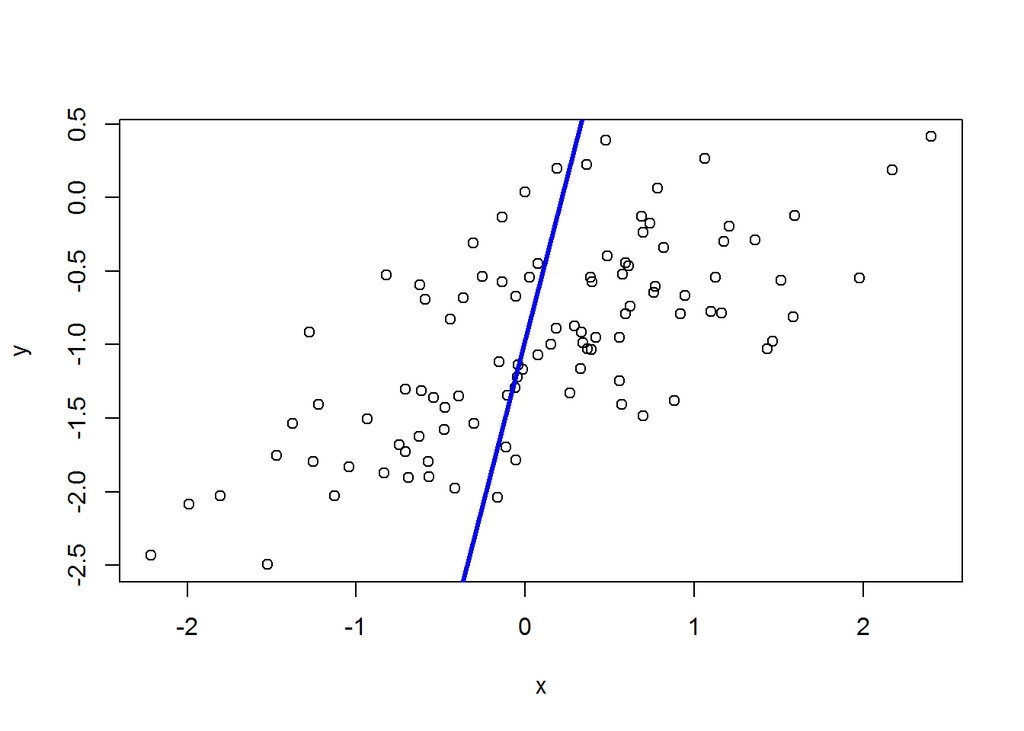

```r
plot(x,y)
abline(Q13.6,lwd=3,col="blue")
```

confidence intervals of all the models

```r
confint(Q13)
```

```
##              2.5 % 97.5 %
## (Intercept) -1.058 -0.961
## x            0.446  0.553
```

```r
confint(Q13.3)
```

```
##              2.5 % 97.5 %
## (Intercept) -1.023 -0.985
## x            0.479  0.521
```

```r
confint(Q13.5)
```

```
##              2.5 % 97.5 %
## (Intercept) -1.115 -0.923
## x            0.393  0.606
```

Questin 14 collinearity handling

```r
set.seed(1)
x1=runif(100)
x2=0.5*x1+rnorm(100)/10
y=2+2*x1+0.3*x2*rnorm(100)
Q14=lm(y~x1+x2)
coef(Q14)
```

```
## (Intercept)          x1          x2
##       2.002       1.982       0.033
```

```r
summary(Q14)
```

```
##
## Call:
## lm(formula = y ~ x1 + x2)
##
## Residuals:
##     Min      1Q  Median      3Q     Max
## -0.2805 -0.0444 -0.0037  0.0404  0.3538
##
## Coefficients:
##             Estimate Std. Error t value Pr(>|t|)
## (Intercept)   2.0021     0.0214   93.47   <2e-16 ***
## x1            1.9824     0.0666   29.76   <2e-16 ***
## x2            0.0330     0.1047    0.32     0.75
## ---
## Signif. codes:  0 '***' 0.001 '**' 0.01 '*' 0.05 '.' 0.1 ' ' 1
##
## Residual standard error: 0.0976 on 97 degrees of freedom
## Multiple R-squared:  0.968,  Adjusted R-squared:  0.968
## F-statistic: 1.49e+03 on 2 and 97 DF,  p-value: <2e-16
```

```r
cor(x1,x2)
```

```
## [1] 0.835
```

predicting with x1

```r
Q14.2=lm(y~x1)
coef(Q14.2)
```

```
## (Intercept)          x1
##           2           2
```

```r
summary(Q14.2)
```

```
##
## Call:
## lm(formula = y ~ x1)
##
## Residuals:
##     Min      1Q  Median      3Q     Max
## -0.2761 -0.0444 -0.0027  0.0412  0.3550
##
## Coefficients:
##             Estimate Std. Error t value Pr(>|t|)
## (Intercept)   2.0015     0.0212    94.2   <2e-16 ***
## x1            2.0000     0.0365    54.8   <2e-16 ***
## ---
## Signif. codes:  0 '***' 0.001 '**' 0.01 '*' 0.05 '.' 0.1 ' ' 1
##
## Residual standard error: 0.0971 on 98 degrees of freedom
## Multiple R-squared:  0.968,  Adjusted R-squared:  0.968
## F-statistic: 3.01e+03 on 1 and 98 DF,  p-value: <2e-16
```

predicting with x2

```r
Q14.3=lm(y~x2)
coef(Q14.3)
```

```
## (Intercept)          x2
##        2.36        2.64
```

```r
summary(Q14.3)
```

```
##
## Call:
## lm(formula = y ~ x2)
##
## Residuals:
##     Min      1Q  Median      3Q     Max
## -0.8081 -0.1942 -0.0127  0.2129  0.5922
##
## Coefficients:
##             Estimate Std. Error t value Pr(>|t|)
## (Intercept)   2.3594     0.0562    42.0   <2e-16 ***
## x2            2.6357     0.1824    14.4   <2e-16 ***
## ---
## Signif. codes:  0 '***' 0.001 '**' 0.01 '*' 0.05 '.' 0.1 ' ' 1
##
## Residual standard error: 0.309 on 98 degrees of freedom
## Multiple R-squared:  0.681,  Adjusted R-squared:  0.677
## F-statistic:  209 on 1 and 98 DF,  p-value: <2e-16
```

afding new observation

```r
x1=c(x1,.1)
x2=c(x2,.8)
y=c(y,6)
```

refitting the models

```r
Q14.4=lm(y~x1+x2)
coef(Q14.4)
```

```
## (Intercept)          x1          x2
##       2.127       0.818       1.979
```

```r
summary(Q14.4)
```

```
##
## Call:
## lm(formula = y ~ x1 + x2)
##
## Residuals:
##     Min      1Q  Median      3Q     Max
## -0.5547 -0.1245 -0.0015  0.1195  2.2083
##
## Coefficients:
##             Estimate Std. Error t value Pr(>|t|)
## (Intercept)   2.1265     0.0662   32.14  < 2e-16 ***
## x1            0.8184     0.1693    4.83  5.0e-06 ***
## x2            1.9791     0.2567    7.71  1.1e-11 ***
## ---
## Signif. codes:  0 '***' 0.001 '**' 0.01 '*' 0.05 '.' 0.1 ' ' 1
##
## Residual standard error: 0.307 on 98 degrees of freedom
## Multiple R-squared:  0.756,  Adjusted R-squared:  0.751
## F-statistic:  152 on 2 and 98 DF,  p-value: <2e-16
```

predicting with x1

```r
Q14.5=lm(y~x1)
coef(Q14.5)
```

```
## (Intercept)          x1
##        2.15        1.78
```

```r
summary(Q14.5)
```

```
##
## Call:
## lm(formula = y ~ x1)
##
## Residuals:
##    Min     1Q Median     3Q    Max
## -0.254 -0.114 -0.062  0.028  3.671
##
## Coefficients:
##             Estimate Std. Error t value Pr(>|t|)
## (Intercept)   2.1503     0.0833    25.8   <2e-16 ***
## x1            1.7836     0.1438    12.4   <2e-16 ***
## ---
## Signif. codes:  0 '***' 0.001 '**' 0.01 '*' 0.05 '.' 0.1 ' ' 1
##
## Residual standard error: 0.388 on 99 degrees of freedom
## Multiple R-squared:  0.608,  Adjusted R-squared:  0.604
## F-statistic:  154 on 1 and 99 DF,  p-value: <2e-16
```

predicting with x2

```r
Q14.6=lm(y~x2)
coef(Q14.6)
```

```
## (Intercept)          x2
##        2.31        2.90
```

```r
summary(Q14.6)
```

```
##
## Call:
## lm(formula = y ~ x2)
##
## Residuals:
##     Min      1Q  Median      3Q     Max
## -0.8443 -0.2034  0.0042  0.2226  1.3768
##
## Coefficients:
##             Estimate Std. Error t value Pr(>|t|)
## (Intercept)   2.3062     0.0606    38.1   <2e-16 ***
## x2            2.8962     0.1914    15.1   <2e-16 ***
## ---
## Signif. codes:  0 '***' 0.001 '**' 0.01 '*' 0.05 '.' 0.1 ' ' 1
##
## Residual standard error: 0.34 on 99 degrees of freedom
## Multiple R-squared:  0.698,  Adjusted R-squared:  0.695
## F-statistic:  229 on 1 and 99 DF,  p-value: <2e-16
```

observe the effect of added observation in Y

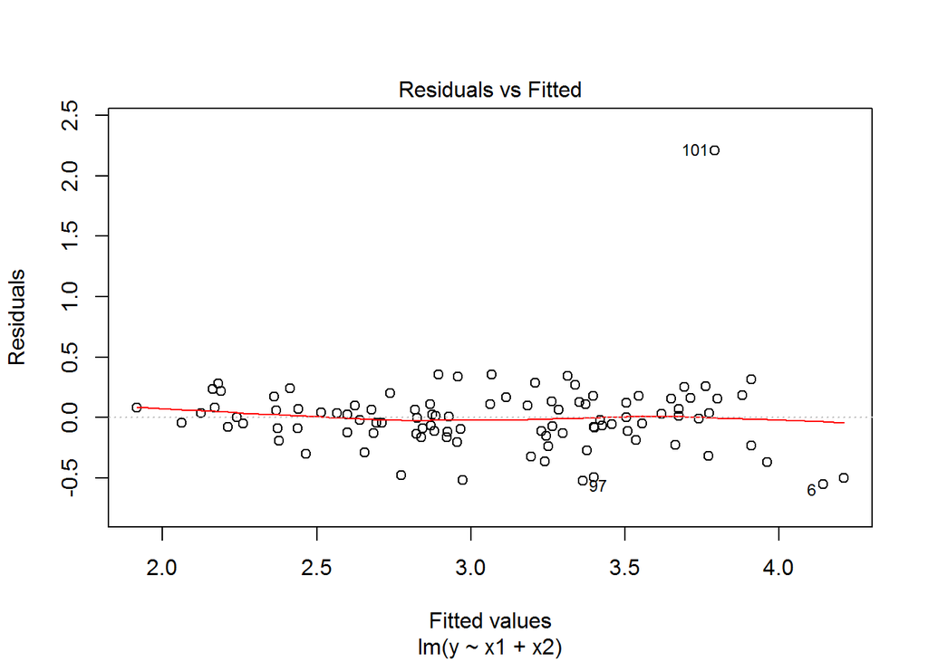

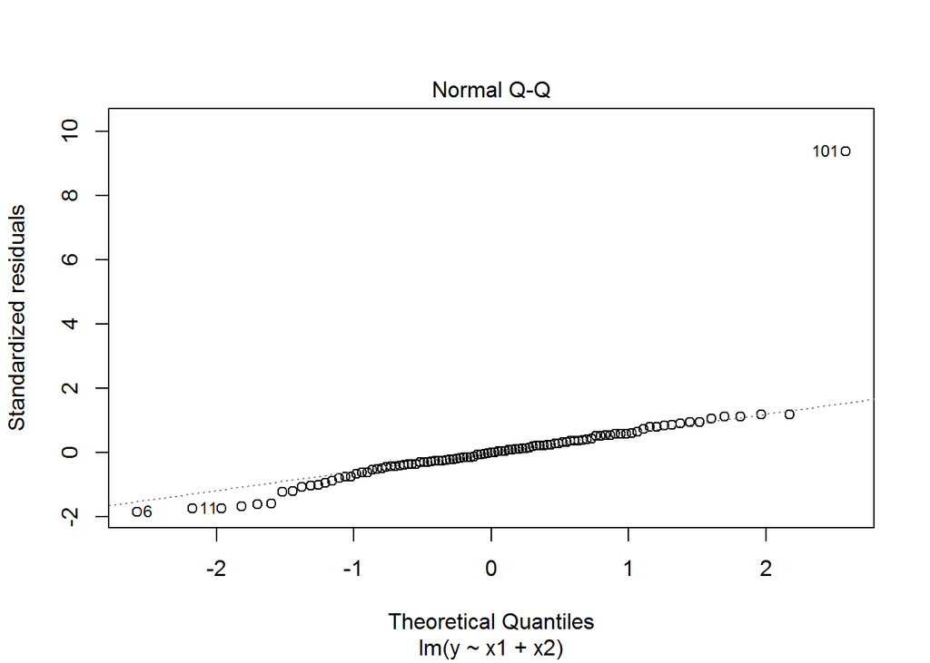

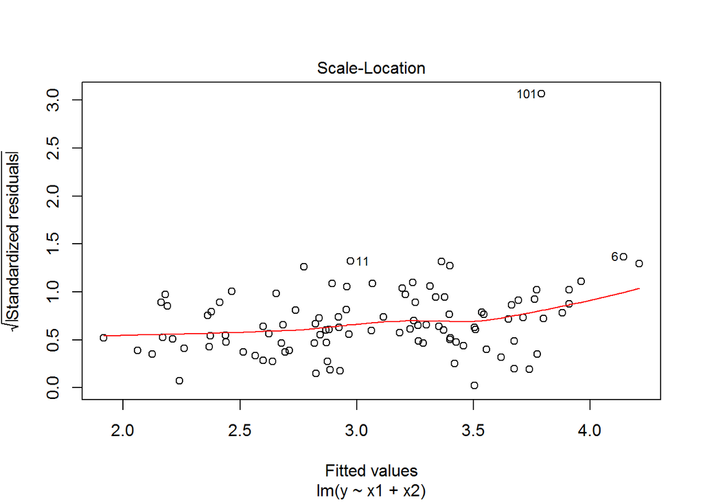

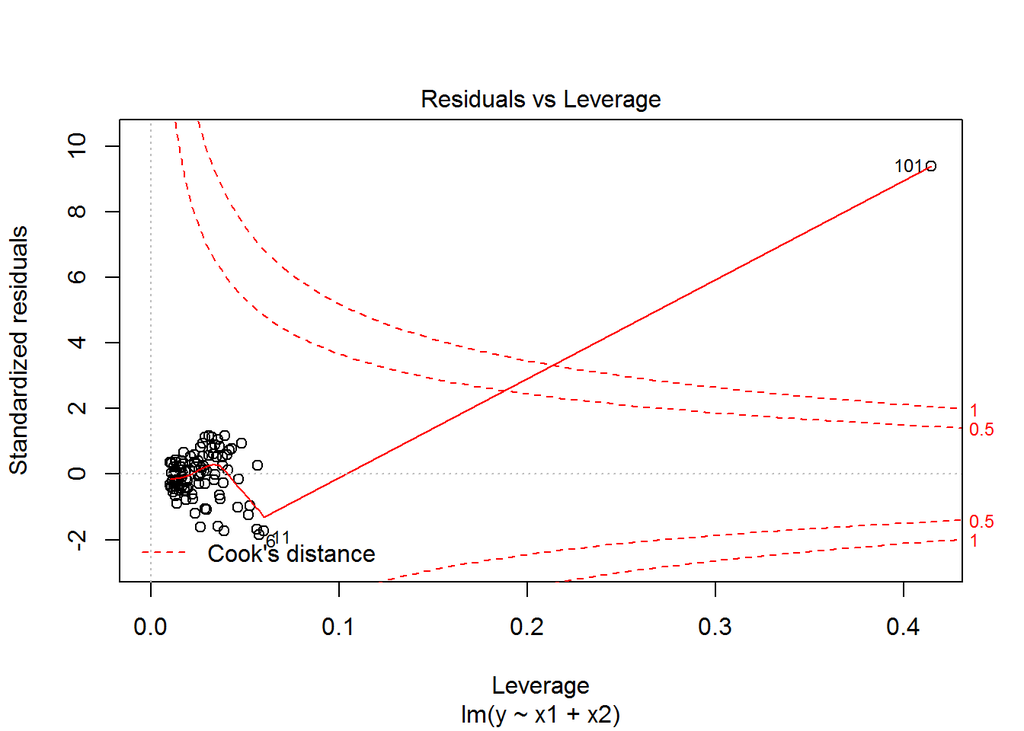

```r
plot(Q14.4)
```

Q15

```r
attach(Boston)
names(Boston)
```

```
##  [1] "crim"    "zn"      "indus"   "chas"    "nox"     "rm"      "age"
##  [8] "dis"     "rad"     "tax"     "ptratio" "black"   "lstat"   "medv"
```

simple linear regression models proportion of residential land zoned for lots over 25,000 sq.ft.

```r
Q15.1=lm(crim~zn)
summary(Q15.1)
```

```
##
## Call:
## lm(formula = crim ~ zn)
##
## Residuals:
##    Min     1Q Median     3Q    Max
##  -4.43  -4.22  -2.62   1.25  84.52
##
## Coefficients:
##             Estimate Std. Error t value Pr(>|t|)
## (Intercept)   4.4537     0.4172   10.67  < 2e-16 ***
## zn           -0.0739     0.0161   -4.59  5.5e-06 ***
## ---
## Signif. codes:  0 '***' 0.001 '**' 0.01 '*' 0.05 '.' 0.1 ' ' 1
##
## Residual standard error: 8.44 on 504 degrees of freedom
## Multiple R-squared:  0.0402, Adjusted R-squared:  0.0383
## F-statistic: 21.1 on 1 and 504 DF,  p-value: 5.51e-06
```

proportion of non-retail business acres per town.

```r
Q15.2=lm(crim~indus)
summary(Q15.2)
```

```
##
## Call:
## lm(formula = crim ~ indus)
##
## Residuals:
##    Min     1Q Median     3Q    Max
## -11.97  -2.70  -0.74   0.71  81.81
##
## Coefficients:
##             Estimate Std. Error t value Pr(>|t|)
## (Intercept)   -2.064      0.667   -3.09   0.0021 **
## indus          0.510      0.051    9.99   <2e-16 ***
## ---
## Signif. codes:  0 '***' 0.001 '**' 0.01 '*' 0.05 '.' 0.1 ' ' 1
##
## Residual standard error: 7.87 on 504 degrees of freedom
## Multiple R-squared:  0.165,  Adjusted R-squared:  0.164
## F-statistic: 99.8 on 1 and 504 DF,  p-value: <2e-16
```

Charles River dummy variable (= 1 if tract bounds river; 0 otherwise). not significant

```r
Q15.3=lm(crim~chas)
summary(Q15.3)
```

```
##
## Call:
## lm(formula = crim ~ chas)
##
## Residuals:
##    Min     1Q Median     3Q    Max
##  -3.74  -3.66  -3.44   0.02  85.23
##
## Coefficients:
##             Estimate Std. Error t value Pr(>|t|)
## (Intercept)    3.744      0.396    9.45   <2e-16 ***
## chas          -1.893      1.506   -1.26     0.21
## ---
## Signif. codes:  0 '***' 0.001 '**' 0.01 '*' 0.05 '.' 0.1 ' ' 1
##
## Residual standard error: 8.6 on 504 degrees of freedom
## Multiple R-squared:  0.00312,    Adjusted R-squared:  0.00115
## F-statistic: 1.58 on 1 and 504 DF,  p-value: 0.209
```

nitrogen oxides concentration (parts per 10 million).

```r
Q15.4=lm(crim~nox)
summary(Q15.4)
```

```
##
## Call:
## lm(formula = crim ~ nox)
##
## Residuals:
##    Min     1Q Median     3Q    Max
## -12.37  -2.74  -0.97   0.56  81.73
##
## Coefficients:
##             Estimate Std. Error t value Pr(>|t|)
## (Intercept)    -13.7        1.7   -8.07  5.1e-15 ***
## nox             31.2        3.0   10.42  < 2e-16 ***
## ---
## Signif. codes:  0 '***' 0.001 '**' 0.01 '*' 0.05 '.' 0.1 ' ' 1
##
## Residual standard error: 7.81 on 504 degrees of freedom
## Multiple R-squared:  0.177,  Adjusted R-squared:  0.176
## F-statistic:  109 on 1 and 504 DF,  p-value: <2e-16
```

average number of rooms per dwelling.

```r
Q15.5=lm(crim~rm)
summary(Q15.5)
```

```
##
## Call:
## lm(formula = crim ~ rm)
##
## Residuals:
##    Min     1Q Median     3Q    Max
##  -6.60  -3.95  -2.65   0.99  87.20
##
## Coefficients:
##             Estimate Std. Error t value Pr(>|t|)
## (Intercept)   20.482      3.364    6.09  2.3e-09 ***
## rm            -2.684      0.532   -5.04  6.3e-07 ***
## ---
## Signif. codes:  0 '***' 0.001 '**' 0.01 '*' 0.05 '.' 0.1 ' ' 1
##
## Residual standard error: 8.4 on 504 degrees of freedom
## Multiple R-squared:  0.0481, Adjusted R-squared:  0.0462
## F-statistic: 25.5 on 1 and 504 DF,  p-value: 6.35e-07
```

proportion of owner-occupied units built prior to 1940.

```r
Q15.6=lm(crim~age)
summary(Q15.6)
```

```
##
## Call:
## lm(formula = crim ~ age)
##
## Residuals:
##    Min     1Q Median     3Q    Max
##  -6.79  -4.26  -1.23   1.53  82.85
##
## Coefficients:
##             Estimate Std. Error t value Pr(>|t|)
## (Intercept)  -3.7779     0.9440   -4.00  7.2e-05 ***
## age           0.1078     0.0127    8.46  2.9e-16 ***
## ---
## Signif. codes:  0 '***' 0.001 '**' 0.01 '*' 0.05 '.' 0.1 ' ' 1
##
## Residual standard error: 8.06 on 504 degrees of freedom
## Multiple R-squared:  0.124,  Adjusted R-squared:  0.123
## F-statistic: 71.6 on 1 and 504 DF,  p-value: 2.85e-16
```

weighted mean of distances to five Boston employment centres.

```r
Q15.7=lm(crim~dis)
summary(Q15.7)
```

```
##
## Call:
## lm(formula = crim ~ dis)
##
## Residuals:
##    Min     1Q Median     3Q    Max
##  -6.71  -4.13  -1.53   1.52  81.67
##
## Coefficients:
##             Estimate Std. Error t value Pr(>|t|)
## (Intercept)    9.499      0.730   13.01   <2e-16 ***
## dis           -1.551      0.168   -9.21   <2e-16 ***
## ---
## Signif. codes:  0 '***' 0.001 '**' 0.01 '*' 0.05 '.' 0.1 ' ' 1
##
## Residual standard error: 7.97 on 504 degrees of freedom
## Multiple R-squared:  0.144,  Adjusted R-squared:  0.142
## F-statistic: 84.9 on 1 and 504 DF,  p-value: <2e-16
```

index of accessibility to radial highways.

```r
Q15.8=lm(crim~rad)
summary(Q15.8)
```

```
##
## Call:
## lm(formula = crim ~ rad)
##
## Residuals:
##    Min     1Q Median     3Q    Max
## -10.16  -1.38  -0.14   0.66  76.43
##
## Coefficients:
##             Estimate Std. Error t value Pr(>|t|)
## (Intercept)  -2.2872     0.4435   -5.16  3.6e-07 ***
## rad           0.6179     0.0343   18.00  < 2e-16 ***
## ---
## Signif. codes:  0 '***' 0.001 '**' 0.01 '*' 0.05 '.' 0.1 ' ' 1
##
## Residual standard error: 6.72 on 504 degrees of freedom
## Multiple R-squared:  0.391,  Adjusted R-squared:  0.39
## F-statistic:  324 on 1 and 504 DF,  p-value: <2e-16
```

full-value property-tax rate per $10,000.

```r
Q15.9=lm(crim~tax)
summary(Q15.9)
```

```
##
## Call:
## lm(formula = crim ~ tax)
##
## Residuals:
##    Min     1Q Median     3Q    Max
## -12.51  -2.74  -0.19   1.07  77.70
##
## Coefficients:
##             Estimate Std. Error t value Pr(>|t|)
## (Intercept) -8.52837    0.81581   -10.4   <2e-16 ***
## tax          0.02974    0.00185    16.1   <2e-16 ***
## ---
## Signif. codes:  0 '***' 0.001 '**' 0.01 '*' 0.05 '.' 0.1 ' ' 1
##
## Residual standard error: 7 on 504 degrees of freedom
## Multiple R-squared:  0.34,   Adjusted R-squared:  0.338
## F-statistic:  259 on 1 and 504 DF,  p-value: <2e-16
```

pupil-teacher ratio by town.

```r
Q15.10=lm(crim~ptratio)
summary(Q15.10)
```

```
##
## Call:
## lm(formula = crim ~ ptratio)
##
## Residuals:
##    Min     1Q Median     3Q    Max
##  -7.65  -3.99  -1.91   1.82  83.35
##
## Coefficients:
##             Estimate Std. Error t value Pr(>|t|)
## (Intercept)  -17.647      3.147   -5.61  3.4e-08 ***
## ptratio        1.152      0.169    6.80  2.9e-11 ***
## ---
## Signif. codes:  0 '***' 0.001 '**' 0.01 '*' 0.05 '.' 0.1 ' ' 1
##
## Residual standard error: 8.24 on 504 degrees of freedom
## Multiple R-squared:  0.0841, Adjusted R-squared:  0.0823
## F-statistic: 46.3 on 1 and 504 DF,  p-value: 2.94e-11
```

1000(Bk - 0.63)^2 where Bk is the proportion of blacks by town.

```r
Q15.11=lm(crim~black)
summary(Q15.11)
```

```
##
## Call:
## lm(formula = crim ~ black)
##
## Residuals:
##    Min     1Q Median     3Q    Max
## -13.76  -2.30  -2.09  -1.30  86.82
##
## Coefficients:
##             Estimate Std. Error t value Pr(>|t|)
## (Intercept) 16.55353    1.42590   11.61   <2e-16 ***
## black       -0.03628    0.00387   -9.37   <2e-16 ***
## ---
## Signif. codes:  0 '***' 0.001 '**' 0.01 '*' 0.05 '.' 0.1 ' ' 1
##
## Residual standard error: 7.95 on 504 degrees of freedom
## Multiple R-squared:  0.148,  Adjusted R-squared:  0.147
## F-statistic: 87.7 on 1 and 504 DF,  p-value: <2e-16
```

lower status of the population (percent).

```r
Q15.12=lm(crim~lstat)
summary(Q15.12)
```

```
##
## Call:
## lm(formula = crim ~ lstat)
##
## Residuals:
##    Min     1Q Median     3Q    Max
## -13.93  -2.82  -0.66   1.08  82.86
##
## Coefficients:
##             Estimate Std. Error t value Pr(>|t|)
## (Intercept)  -3.3305     0.6938    -4.8  2.1e-06 ***
## lstat         0.5488     0.0478    11.5  < 2e-16 ***
## ---
## Signif. codes:  0 '***' 0.001 '**' 0.01 '*' 0.05 '.' 0.1 ' ' 1
##
## Residual standard error: 7.66 on 504 degrees of freedom
## Multiple R-squared:  0.208,  Adjusted R-squared:  0.206
## F-statistic:  132 on 1 and 504 DF,  p-value: <2e-16
```

median value of owner-occupied homes in $1000s.

```r
Q15.13=lm(crim~medv)
summary(Q15.13)
```

```
##
## Call:
## lm(formula = crim ~ medv)
##
## Residuals:
##    Min     1Q Median     3Q    Max
##  -9.07  -4.02  -2.34   1.30  80.96
##
## Coefficients:
##             Estimate Std. Error t value Pr(>|t|)
## (Intercept)  11.7965     0.9342   12.63   <2e-16 ***
## medv         -0.3632     0.0384   -9.46   <2e-16 ***
## ---
## Signif. codes:  0 '***' 0.001 '**' 0.01 '*' 0.05 '.' 0.1 ' ' 1
##
## Residual standard error: 7.93 on 504 degrees of freedom
## Multiple R-squared:  0.151,  Adjusted R-squared:  0.149
## F-statistic: 89.5 on 1 and 504 DF,  p-value: <2e-16
```

complete model

```r
Q15compl=lm(crim~.,data = Boston)
summary(Q15compl)
```

```
##
## Call:
## lm(formula = crim ~ ., data = Boston)
##
## Residuals:
##    Min     1Q Median     3Q    Max
##  -9.92  -2.12  -0.35   1.02  75.05
##
## Coefficients:
##              Estimate Std. Error t value Pr(>|t|)
## (Intercept)  17.03323    7.23490    2.35   0.0189 *
## zn            0.04486    0.01873    2.39   0.0170 *
## indus        -0.06385    0.08341   -0.77   0.4443
## chas         -0.74913    1.18015   -0.63   0.5259
## nox         -10.31353    5.27554   -1.95   0.0512 .
## rm            0.43013    0.61283    0.70   0.4831
## age           0.00145    0.01793    0.08   0.9355
## dis          -0.98718    0.28182   -3.50   0.0005 ***
## rad           0.58821    0.08805    6.68  6.5e-11 ***
## tax          -0.00378    0.00516   -0.73   0.4638
## ptratio      -0.27108    0.18645   -1.45   0.1466
## black        -0.00754    0.00367   -2.05   0.0407 *
## lstat         0.12621    0.07572    1.67   0.0962 .
## medv         -0.19889    0.06052   -3.29   0.0011 **
## ---
## Signif. codes:  0 '***' 0.001 '**' 0.01 '*' 0.05 '.' 0.1 ' ' 1
##
## Residual standard error: 6.44 on 492 degrees of freedom
## Multiple R-squared:  0.454,  Adjusted R-squared:  0.44
## F-statistic: 31.5 on 13 and 492 DF,  p-value: <2e-16
```

coeff

```r
coef(Q15compl)
```

```
## (Intercept)          zn       indus        chas         nox          rm
##    17.03323     0.04486    -0.06385    -0.74913   -10.31353     0.43013
##         age         dis         rad         tax     ptratio       black
##     0.00145    -0.98718     0.58821    -0.00378    -0.27108    -0.00754
##       lstat        medv
##     0.12621    -0.19889
```

```r
q15=c(coef(Q15compl)[-1])
q15
```

```
##        zn     indus      chas       nox        rm       age       dis
##   0.04486  -0.06385  -0.74913 -10.31353   0.43013   0.00145  -0.98718
##       rad       tax   ptratio     black     lstat      medv
##   0.58821  -0.00378  -0.27108  -0.00754   0.12621  -0.19889
```

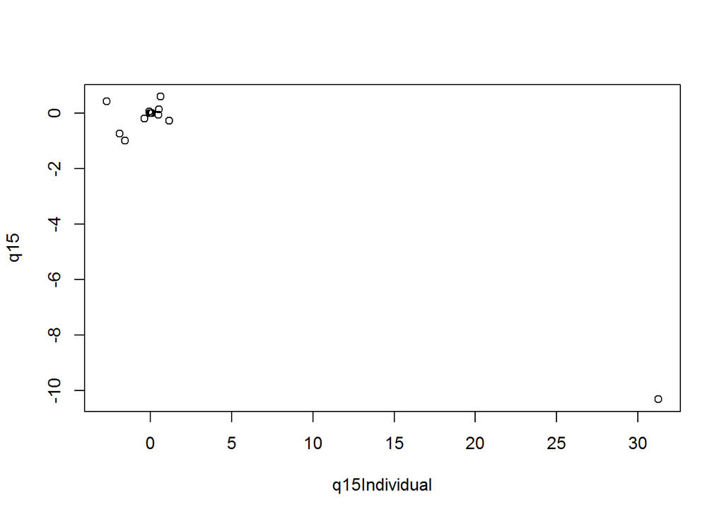

```r
q15Individual=c(coef(Q15.1)[-1],coef(Q15.2)[-1],coef(Q15.3)[-1],coef(Q15.4)[-1],coef(Q15.5)[-1],
coef(Q15.6)[-1],coef(Q15.7)[-1],coef(Q15.8)[-1],coef(Q15.9)[-1],coef(Q15.10)[-1],
coef(Q15.11)[-1],coef(Q15.12)[-1],coef(Q15.13)[-1])
plot(q15Individual,q15)
```